# Projet 20 : Sur des modèles de pêcherie

*Un projet porté par Chaïmaa AOUAME, Hugues DREYFUS, Aya NAIT-NADIR & Anh Hung NGÔ*

```python
from IPython.display import HTML

HTML('''
    <script>
        code_show = true;
        function code_toggle() {
            if (code_show){
                $('div.input').hide();
            } else {
                $('div.input').show();
            }
            code_show = !code_show
        }
        $( document ).ready(code_toggle);
    </script>
    <form action="javascript:code_toggle()">
        <input type="submit" value="Click here to toggle on/off the raw code.">
    </form>
''')
```

```python
# Importation

import matplotlib.pyplot as plt
import numpy as np
from numpy.linalg import inv
from ipywidgets import interact, fixed, FloatSlider
from IPython.display import display, Latex
import random as random
import sympy as sym
from scipy.integrate import solve_ivp
```

## Introduction

Notre projet consiste en l'étude de différents modèles de pêcheries afin d'observer les paramètres influençant l'évolution de stocks de poissons, et ce, en s'inspirant des modèles proposé dans l'article du Professeur Ali Moussaoui, professeur à l'université de Tlemcen en Algérie.

Pour notre analyse, nous étudierons des modèles de plus en plus complexes, prenant en compte de plus de paramètres. Pour chaque modèle, nous étudierons l'évolution des stocks (ainsi que d'autres paramètres tels que l'effort de pêche) au cours du temps, les situations d'équilibre ainsi que leur attractivité.

Nous commencerons par un modèle simplifié, appelé modèle purement écologique pour pouvoir appréhender le sujet et les méthodes à mobiliser pour les modèles suivants. Ensuite nous chercherons à comprendre un modèle prenant en compte un premier paramètre économonique, dit modèle bio-économique. Puis nous analyserons un modèle économique plus complexe que nous nommerons modèle avec demande. Comme nous essayons de nous rapprocher d'un modèle de plus en plus proche de la réalité, nous considérerons en avant-dernier un modèle prenant en compte le déplacement des stocks entre différents sites, le modèle multi-sites. Enfin pour s'assurer de notre compréhension du sujet nous introduirons une nouvelle variable, à savoir la cohabitation entre deux espèces de poissons dans un même espace : modèle bi-espèces.

*Pour vous assurer de réaliser une lecture dans de bonnes conditions, si vous décidez de réexécuter tout le code (ce qui ne prend pas plus de quelques secondes), il est conseillé de rentrer une valeur quelconque (même invalide) dans l'* `input` *dans la section 5.C, et ce pour permettre d'utiliser les* `interact` *en toute sérénité.*

### Table des matières

- Un modèle purement écologique
  - Etude liminaire du modèle
  - Etude des points d'équilibre
  - Illustration numérique
  - Une gestion optimale des stocks ?
- Un modèle bio-économique
  - Une première étude du modèle
  - Etude analytique des points d'équilibre
  - Illustration numérique
  - Etude de la capturabilité optimale
- Un deuxième modèle bio-économique : la demande en jeu
  - Justification du modèle
  - Etude des points d'équilibre
  - Illustration numérique des résultats
- Un modèle multi-sites
  - Etude liminaire du modèle
  - Etude numérique du modèle
  - Comparaison des modèles 3 et 4
- Un modèle bi-espèces pour aller plus loin
  - Présentation du modèle
  - Représentation numérique
  - Cas d'école
- Conclusion
- Bibliographie
- Annexes

## 1. Un modèle purement écologique

Retour à la table des matières

Nous allons étudier un premier modèle dit purement écologique au sens où il *ne prend en compte que les limitations intrinsèques du milieu* et parce que l'effort de pêche est considéré comme une variable constante (qui pourrait dans l'absolu représenter une prédation non-anthropique).

Nous commencerons par comprendre comment ce modèle est construit—quels sont ses paramètres et que représentent-ils—puis verront quelles sont les conditions pour avoir un stock stationnaire et la stabilité de tels points d'équilibre. Enfin, nous représenterons à l'aide d'un script Python l'évolution d'un tel modèle avant de conclure sur un effort de pêche optimal.

### A) Etude liminaire du modèle

Le modèle étudié est le suivant : $$\boxed{\frac{dn}{dt}(t)=r n(t)\left(1-\frac{n(t)}{K}\right)-qEn(t)} \tag 1$$

dont le membre de droite peut être être réécrit sous une forme polynomiale : $$\frac{dn}{dt}(t) = -\frac{r}{K} n^2(t) + (r - qE)n(t) \tag{1a}$$

L'inconnue du système est la **quantité $n$ de poisson**, dont les variations sont exprimées par sa dérivée temporelle première $\frac{dn(t)}{dt}$. Les autres paramètres sont :

- La **capacité limite du milieu $K$** (un réel positif) qui a un effet de frein sur l'évolution du stock. Plus celle-ci est grande, moins la variation du stock sera importante (et inversement). En effet, toutes choses égales par ailleurs, la variation instantanée du stock $\frac{dn}{dt}$ à un instant $t_0$ est inversement proportionelle à $-K$ à une constante $n(t_0)(r - qE)$ près. Néanmoins, la fonction inverse étant asymptotique en l'infini, $K$ a un effet relativement limité sur $\frac{dn}{dt}$ car borné par la constante suscitée.
- Le **taux de croissance de l'espèce de poisson considérée $r$** (un réel positif). Cela correspond à la force motrice du stock. En effet, à un instant $t_0$ donné, l'évolution instantanée du stock est cette fois-ci proportionelle à $r$ à une constante $-qEn(t_0)$ près. Intuitivement, cela est aisément compréhensible car plus vite les poissons se reproduisent, plus il y aura de poissons en mesure de se reproduire et donc plus la variation de stock sera importante.
- L'**effort de pêche $E$** (un réel positif), qui correspond à une capacité de pêche déterminé par le nombre de bateaux engagés dans la pêche, multiplié par l'activité du bateau. Il a aussi un effet négatif sur l'évolution du stock, $\frac{dn}{dt}$ étant proportionnel à $-E$ à une constante $rn(t_0)-\frac{r}{K}n^2(t_0)$ près.
- La **capturabilité $q$** (un réel compris entre 0 et 1), soit la probabilité pour une espèce de poisson d'être capturé pendant une unité de temps. Elle a un effet en tout point comparable à celui de l'effort de pêche.

Au vu des différents paramètres, l'équation $(1)$ peut être comprise comme l'**interaction de deux facteurs : l'évolution d'une population dans un milieu avec une capacité d'accueil finie et l'action de la pêche**. $$\frac{dn(t)}{dt} = r n(t)\left(1 - \frac{n(t)}{K}\right) - qEn(t) = \mathrm{evolution~libre~de~la~population - impact~de~la~peche}$$
Avec $r n(t)(1 - \frac{n(t)}{K})$ l'évolution libre de la population (selon le modèle logistique de Verhulst), qui n'est limitée que par la capacité d'accueil du milieu et le taux de croissance de la population, et $- qEn(t)$ l'impact de la pêche, qui dépend de l'effort de pêche et de la capturabilité. La quantité de poisson prélevée à l'instant $t$ est donc $\Delta n_\mathrm{pêche}(t)=qEn(t)$.

### B) Etude des points d'équilibre

Le stock est dit stable quand son évolution est nulle, soit $\frac{d n}{d t} = 0$. Pour simplifier l'étude, nous nous proposons de réécrire l'équation sous la forme : $$\frac{d n}{d t} = r n(t)\left( 1 - \frac{n(t)}{K} \right) - qEn(t) = \left( r \left(1- \frac{n(t)}{K} \right) - qE \right) n(t) \tag{1b}$$
Nous nous retrouvons avec une équation produit nul, ce qui nous amène pour un stock stationnaire aux deux cas de figure suivants :

- soit $n(t) = \boxed{n_1 = 0}$, il n'y a plus de poissons ;
- soit $r \left(1- \frac{n(t)}{K} \right) - qE = 0 \Leftrightarrow 1-\frac{n(t)}{K} = \frac{qE}{r} \Leftrightarrow n(t) = K(1-\frac{qE}{r}) =\boxed{n_2 = \frac{K(r-qE)}{r}}$, second point d'équilibre que nous allons étudier plus en avant ci-après.

Il est important de rappeler que nous étudions **un stock de poissons, qui ne peut donc être négatif** (sauf à ce que des anti-poissons soit découvert dans un avenir proche). Nous pouvons donc poser une condition supplémentaire sur les paramètres de l'équation $(1)$ si nous nous plaçons dans le cas d'une pêche durable : $n_2 > 0 \Longrightarrow qE < r$, soit que la capture effective des poissons doit être moins importante que leur taux de reproduction.

Dans ce cas de figure, il semble intéressant d'étudier la stabilité d'un tel point d'équilibre.
La stabilité ou attractivité d'un point d'équilibre désigne la propension du modèle à retourner à cet état après une perturbation. Pour ce faire, nous réécrivons l'équation $(1)$ sous la forme suivante : $$ \frac{dn(t)}{dt}= n(t)\frac{K(r-qE)-rn(t)}{K}=\frac{rn(t)}{K}\left(n_2-n(t)\right) \tag{1c}$$

Nous définissons une fonction qui mesure la grandeur d'une telle perturbation $\varepsilon_i : t \longmapsto n(t) - n_i$, dont nous allons étudier la a-stabilité. Nous définissons également la fonction $f : n(t) \longmapsto \frac{rn(t)}{K}\left(n_2-n(t)\right)$.

De fait, l'évolution d'une telle perturbation suit la loi de $f$ : $\dot \varepsilon_i (t) = \frac{dn}{dt}(t) = f(n)$. Si l'on considère une petite variation alors nous pouvons assimiler le stock réel au point d'équilibre : $\varepsilon_i(t) \longrightarrow 0 \Longrightarrow n(t) \simeq n_i$, alors par équivalence nous pouvons en déduire que : $$\dot \varepsilon_i(t) = f(n_i) + \varepsilon_i f'(n_i) + o\left(\|t\|\right) = \varepsilon_i f'(n_i)+ o\left(\|t\|\right)$$

En effet, comme nous étudions un point d'équilibre, alors $f(n_i)= 0$. Si l'on pose $f'(n_i) = a_i$, cela correspond au problème de Cauchy : $\dot y(t) = a_i y$ qui est a-instable pour un $a_i$ positif et a-stable pour un $a_i$ négatif. Etudions la dérivée de $f(n)$ aux points $n_1$ et $n_2$ : $$f'(n)= \frac{r}{K}n_2 - \frac{2r}{K} n(t) \Longrightarrow \begin{cases} f'(n_1)= +\frac{r}{K}n_2 \\ f'(n_2)= -\frac{r}{K}n_2 \end{cases} \Longleftrightarrow \begin{cases} a_1 > 0,~\rm instable \\ a_2 < 0,~\rm stable \end{cases}$$

Enfin, nous pouvons en déduire que le point $n_1$ est a-instable, c'est-à-dire qu'il est répulsif, tandis que le point $n_2$ est a-stable, c'est-à-dire attractif. D'un point de vue pratique, cela signifie que qu'importe la faiblesse du stock, celui-ci augmentera pour atteindre la limite $n(t)\longrightarrow n_2$ (ou s'il est trop fort il diminuera pour atteindre cette même limite).

### C) Illustration numérique

Pour notre modélisation numérique nous avons choisi d'utiliser un modèle de Runge-Kutta 2. C'est un modèle d'ordre 2 et pour vérifier sa stabilité nous faisons varier le pas de temps à l'aide d'un curseur. Notre modèle nous donne des résultats cohérents, c'est donc un modèle adapté à notre étude.

```python
def RK2(r, K, q, c, E, n0, ti, tf, dt):
    f = lambda n : r*n*(1-n/K) - q*E*n

    N = int((tf-ti)/dt)+1
    T = np.zeros(N)
    n = np.zeros(N)

    n[0] = n0
    T[0] = ti

    for i in range(1,N):
        T[i] = ti + i*dt
        n[i] = n[i-1] + dt*f(n[i-1]+dt/2*f(n[i-1]))

    display(Latex(("Etude des solutions d'équilibre :")))
    display(Latex(f'Stock final : $n^f = {round(n[N-1], 3)}$ ; quantité pêchée finale : $Δn_p^f = {round(n[N-1]*q*E,3)}$'))
    display(Latex(f"Point d'équilibre attractif pour $E < r/q$ : $n_2 = {round(K/r * (r-q*E), 3)}$"))
    return T, n
```

```python
r = (0.5, 1.2, 0.1)                   # taux de croissance
K = 20                                # capacité limite du milieu
q = (0.4, 1, 0.1)                     # paramètre de capturabilité
c = 3                                 # coût unitaire de l’effort de pêche

E = (0, 2*1.2/0.4, 0.1)               # effort de pêche
n0 = (0, K, 0.01)                     # quantité de poissons initiale
ti = 0; tf = 250                      # durée de simulation
dt = (0.01, 1, 0.01)                  # différents pas de temps

@interact
def interact_plot(r=r, K=fixed(K), q=q, c=fixed(c), E=E, n0=n0, ti=fixed(ti), tf=fixed(tf), dt=dt):
    T, n = RK2(r, K, q, c, E, n0, ti, tf, dt)
    print()
    if E > r/q:
        display(Latex("Régime actuel : surpêche"))
    else:
        display(Latex("Régime actuel : sous-pêche"))
    display(Latex(f"Effort de pêche optimal théorique : $E_o ={round(r/(2*q),3)}$"))

    fig, ax = plt.subplots(1,1, figsize=(14, 5))
    ax.plot(T, n, '-b', label = 'Stock')
    ax.plot(T, n*q*E, '-r', label = 'Capture')
    ax.set_xlabel('Temps écoulé')
    ax.set_ylabel('Poissons (stock/capturés)')
    ax.set_title('Évolution du stock et de la capture par la pêche en fonction du temps')
    ax.legend(bbox_to_anchor=(1.05, 1.0), loc="upper left")
    ax.grid()
```

```
interactive(children=(FloatSlider(value=0.8, description='r', max=1.2, min=0.5), FloatSlider(value=0.600000000…
```

Le graphique ci-dessus présente les résultats de la modélisation numérique notre modèle. Nous pouvons faire varier les paramètres $r$ et $q$ qui définissent l'effort de pêche optimal comme nous le verrons par la suite. Nous pouvons aussi vérifier rapidement l'attractivité des points d'équilibre.

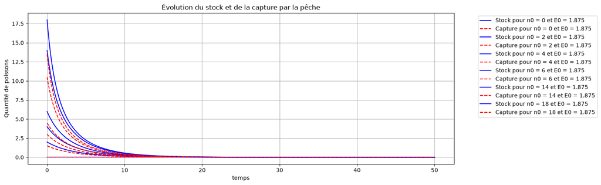

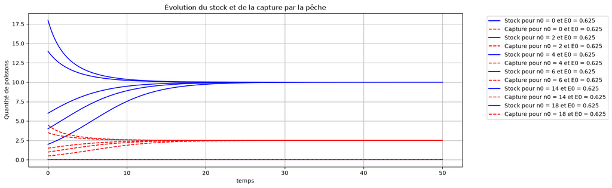

```python
r = 0.5                               # taux de croissance
K = 20                                # capacité limite du milieu
q = 0.4                               # paramètre de capturabilité
c = 3                                 # coût unitaire de l’effort de pêche

e = [1.5*r/q , r/q/2]                 # effort de pêche entre 0 et la limite du modèle
n0 = 12                               # quantité de poissons initiale
ti = 0; tf = 50                       #durée de simulation
dt = 0.1                              #différents pas de temps

ns0 = [0, int(n0/6), int(n0/3), int(n0/2), int(1.2*n0), int(1.5*n0)]   #différents points de départ
################## boucles #########################
for E in e :
  f = lambda x : r*x*(1-x/K) - q*E*x
################## affichage #############################
  fig, ax = plt.subplots(1,1, figsize=(14, 5))
  ax.grid()
  for ni in ns0 :
    N = int((tf-ti)/dt)+1
    Ts = np.zeros(N)
    ns = np.zeros(N)

    ns[0] = ni
    Ts[0] = ti

    for i in range(1,N):
      Ts[i] = ti + i*dt
      ns[i] = ns[i-1] + dt*f(ns[i-1]+dt/2*f(ns[i-1]))

    ax.plot(Ts, ns, '-', label = f'Stock pour n0 = {ni} et E0 = {E}', color = 'blue')
    ax.plot(Ts, ns*q*E, '--', label = f'Capture pour n0 = {ni} et E0 = {E}', color = 'red')
    ax.set_xlabel('temps')
    ax.set_ylabel('Quantité de poissons')
    ax.set_title('Évolution du stock et de la capture par la pêche')
    ax.legend(bbox_to_anchor=(1.05, 1.0), loc="upper left")
```

Pour montrer l'attractivité des points d'équilibres étudiés, nous effectuons de simulations avec plusieurs populations $n_0$ de départ, simulations sur un temps suffisamment long pour un atteindre un équilibre asymptotique. Ces deux graphiques montrent bien l'attractivité des solutions d'équilibre. Nous étudions alors deux cas de figure :

- $E > \frac{r}{q}$ : Nous sommes dans un régime de surpêche : le point d'équilibre attractif est $n_1 = 0$ ici. Ceci paraît assez cohérent physiquement puisque le point $n_2$ donne un stock de poisson négatif.
- $E < \frac{r}{q}$ : Nous nous retrouvons dans un cas de régime de pêche durable ou stable : le point d'équilbre attractif est bien $n_2$ comme trouvé théoriquement.

### D) Une gestion optimale des stocks ?

Ainsi, ce premier modèle assez simple permet de montrer les liens entre les différents paramètres et de mettre en exergue les différents points d'équilibres ainsi que leur assujettissement à la relation entre effort de pêche et la capacité de reproduction, la résilience d'une espèce.  
Nous pouvons de plus trouver un effort de pêche optimal théorique en cherchant une configuration qui permet d'avoir à la fois, un nombre de poissons capturé et un stock maximaux. Cet effort de pêche (détails des calculs en annexe) a pour valeur :

$$ \boxed{E_{opt}^{th} = \frac{r}{2q}} $$

Nous pouvons l'illustrer numériquement en traçant l'évolution du stock restant et de poissons capturés sur un même graphique, puis en faisant ensuite évoluer les paramètres pour chercher un effort de pêche $E_{opt}^{num}$ qui maximise les deux courbes. Nous voyons alors que celui-ci dépend de $r$ et $q$, nous pouvons alors comparer $E_{opt}^{num}$ et $E_{opt}^{th}$, et remarquer qu'ils sont identiques.

## 2. Un modèle bio-économique

Retour à la table des matières

Nous allons étudier un deuxième modèle similaire au premier mais qui cette fois prend en compte l'évolution de l'effort de pêche. Nous introduisons donc une première complexité qui témoigne de la possibilité d'investir dans l'économie de la pêche en fonction de la rentabilité de cette activité. Nous suivrons la même progression que pour le modèle précédent mais nous étudierons cette fois-ci la capturabilité optimale des poissons.

### A) Etude liminaire du modèle

On travaille cette fois avec un système couplé d’équations différentielles : $$\boxed{ \begin{cases} \frac{dn}{dt}(t) = r n(t)\left(1-\frac{n(t)}{K}\right) - q E(t)n(t) \\ \frac{dE}{dt}(t) = (pqn(t)-c) E(t) \end{cases}} \tag 2 $$ où $c>0$ représente le coût unitaire de l'effort de pêche et $p>0$ le prix unitaire de vente du poisson.

Dans ce système d'équations, la première qui décrit l'évolution du stock est identique à celle du modèle précédent.

On a cependant une nouvelle équation qui décrit l'évolution de l'effort de pêche en fonction du prix du poisson, de sa capturabilité et du coût unitaire de l'effort de pêche. Celle-ci assujettit l'investissement dans la pêche (l'évolution de l'effort de pêche $\frac{dE}{dt}$) à sa rentabilité : tant que le prix de revient ($pqn(t) -c$) est positif, l'effort de pêche augmente, mais dès qu'il devient négatif il diminue.

Ce modèle prend en considération la variation de l'effort de pêche au cours du temps telle que décrit ci-avant. Ce modèle est plus réaliste et permet de concilier les durabilités économique et écologique de l'exploitation des ressources halieutiques. Ci-dessous une modélisation numérique de ce modèle.

```python
# La solution au cours du temps de ce système en fonction des paramètres du modèle.

############## fonction de résolution ############################
def RK2_1e_bio_eco(r, K, q, p, c, E0, n0, ti, tf, dt):
    fn = lambda n, E : r*n*(1-n/K) - q*E*n
    fE = lambda n, E : (p*q*n - c)*E

    N = int((tf-ti)/dt)+1
    T = np.zeros(N)

    n = np.zeros(N)
    E = np.zeros(N)

    n[0] = n0
    E[0] = E0
    T[0] = ti

    for i in range(1,N):
        T[i] = ti + i*dt

        n_temps = n[i-1]+dt/2*fn(n[i-1], E[i-1])
        E_temps = E[i-1]+dt/2*fE(n[i-1], E[i-1])

        n[i] = n[i-1] + dt*fn(n_temps, E_temps)
        E[i] = E[i-1] + dt*fE(n_temps, E_temps)

    return T, n, E
```

```python
################### Paramètres ##############################################
r = 0.5                                   # taux de croissance
K = 20                                    # capacité limite du milieu
q = 0.4                                   # paramètre de capturabilité
p = 0.5                                   # prix unitaire de vente du poisson
c = 1                                     # coût unitaire de l’effort de pêche

E0 = (0, r/q, 0.1)                        # effort de pêche initial
n0 = (0, K, 1)                            # quantité de poissons initiale

ti = 0; tf = 100
dt = (0.01, 1, 0.01)
#############################################################################


@interact
def interact_bioeco(r=fixed(r), K=fixed(K), q=fixed(q), p=fixed(p), c=fixed(c), E0=E0, n0=n0, ti=fixed(ti), tf=fixed(tf), dt=dt):
    #c = p*q*K/2
    #print(f"Cas où c = {c} < pqK")
    T, n, E = RK2_1e_bio_eco(r, K, q, p, c, E0, n0, ti, tf, dt)
    print('n fin = ', round(n[-1],3), '; E fin = ',round(E[-1],3))
    print(f"n_th = {c/(p*q)}, E_th = {r/q * (1 - c/(p*q*K))}")
    fig, ax = plt.subplots(1,3, figsize=(14, 5))
######################################################################### premiere partie :
    ax[0].plot(T, n, '-b')
    ax[0].set_title("Évolution de la quantité de poissons")
    ax[0].grid()

    ax[1].plot(T, E, '-r')
    ax[1].set_title("Évolution de l'effort de pêche")
    ax[1].grid()

    ax[2].plot(n, E, '--vr')
    ax[2].set_title("E = f(n)")
    ax[2].grid()
```

```
interactive(children=(FloatSlider(value=0.6000000000000001, description='E0', max=1.25), IntSlider(value=10, d…
```

On remarque que les évolutions de stocks et d'effort de pêches suivent des évolutions oscillantes, puis se stabilisent autour d'un couple de valeurs qui correspondraient donc à un équilibre stable. Nous avons choisi tracer ces évolutions sur deux graphiques différents au vu de la différence d'échelle. Nous allons déterminer ces points d'équilibre analytiquement puis les vérifier numériquement.

### B) Etude analytique des points d'équilibre

Pour trouver les points d'équilibre du système, l'on résoud : $\frac{dn}{dt}(t) = 0$ et $\frac{dE}{dt}(t) = 0$. On peut réécrire l'équation $(2)$ sous la forme suivante : $$ \begin{cases} \frac{dn}{dt}(t) = r n(t)\left(1-\frac{n(t)}{K}\right) - q E(t)n(t) \\ \frac{dE}{dt}(t) = (pqn(t)-c) E(t) \end{cases} \Longleftrightarrow \begin{cases} \frac{dn}{dt}(t) = \left(r\left(1-\frac{n(t)}{K}\right) - q E(t)\right)n(t) \\ \frac{dE}{dt}(t) = (pqn(t)-c) E(t) \end{cases} \tag {2a} $$

- Le premier point d'équilibre est trouvable intuitivement si l'on prend le couple de solutions nulles : **$\boxed{(n_1, E_1) = (0, 0)}$**.
- Dans le deuxième cas de figure, on considère que seul l'effort de pêche est nul (c.-à-d. qu'il n'y a pas de prédation anthropique) : $E_2 = 0$ et $n_2 \not = 0$. Le premier cas devient : $$\frac{dn}{dt}(t) = 0 = \left(r\left(1-\frac{n_2}{K}\right) - q E_2\right)n_2 = \left(1-\frac{n_2}{K}\right)n_2 \Longleftrightarrow n_2 = K$$ D'où **$\boxed{(n_2, E_2) = (K, 0)}$**.
- Dans le troisième et dernier cas de figure, si l'on considère que ni le stock ni l'effort de pêche ne peuvent être nul alors le second cas donne : $$\frac{dE}{dt}(t) = 0 = pqn_3-c \Longleftrightarrow n_3 = \frac{c}{pq}$$ Puis en injectant cette solution le premier cas, on trouve : $$\frac{dn}{dt}(t) = 0 = r n_3\left(1-\frac{n(t)}{K}\right) - q E_3n_3 = r \left(1-\frac{c}{pqK}\right) - q E_3 $$ $$\Longleftrightarrow E_3 = \frac{r}{q}\left(1- \frac{c}{pqK}\right) $$ Soit **$\boxed{(n_3, E_3)= \left(\frac{c}{pq},\frac{r}{q}\left(1- \frac{c}{pqK}\right)\right)}$**.

On se retrouve alors avec trois points d'équilibre où le ratio $\frac{c}{pqK}$ conditionne l'attractivité des solutions et leur signification physique. En effet, une fois encore l'effort de pêche étant une grandeur positive, alors on peut en conclure que $c<pqk$. Autrement $c>pqK \Longrightarrow 1- \frac{c}{pqK} < 0 \Longrightarrow E_3 < 0$, ce qui est impossible. Nous nous penchons maintenant sur l'attractivité des solutions dans le cas où $c < pqK$.

On étudie la stabilité des points 2 et 3. Vous trouverez en annexe les détails de calculs.  
Le principe est le suivant :

- on linéarise les expressions de $f (X)= \frac{dn}{dt}(t)$ et $g(X)=\frac{dE}{dt}(t)$,
- on réécrit le système obtenue sous la forme d'un système matriciel $F = A(X-X_i)$ avec $A = \left[\begin{matrix}\partial_1 \dot n & \partial_2 \dot n \\ \partial_1 \dot E & \partial_2 \dot E \end{matrix}\right]$,
- on étudie les valeurs propres de cette matrice.

Après étude nous trouvons que le point d'équilibre $(n_2, E_2)$ est **instable** (c'est un point de selle). Puis en suivant la même démarche, nous trouvons que le point d'équilibre $(n_3, E_3)$ est **stable**.

### C. Illustration numérique

Nous allons illustrer la stabilité de ces points d'équilibre numériquement. Pour celà nous allons distinguer deux cas et nous procéderons de la même façons que précédemment, c'est-à-dire que l'on choisira différents points de départ et que l'on tracera l'évolution de l'effort de pêche en fonction du stock de poissons.

```python
################### Paramètres ##############################################
r = 0.5                                   # taux de croissance
K = 20                                    # capacité limite du milieu
q = 0.4                                   # paramètre de capturabilité
p = 0.5                                   # prix unitaire de vente du poisson
c = 1                                     # coût unitaire de l’effort de pêche

E0 = (0, r/q, 0.1)                        # effort de pêche initial
n0 = (0, K, 1)                            # quantité de poissons initiale

ti = 0; tf = 100
dt = (0.01, 1, 0.01)
#############################################################################


@interact
def interact_bioeco(r=fixed(r), K=fixed(K), q=fixed(q), p=fixed(p), c=fixed(c), E0=E0, n0=n0, ti=fixed(ti), tf=fixed(tf), dt=dt):
    c = p*q*K/2
    display(Latex(f"Cas où $c = {c} < pqK$"))
    T, n, E = RK2_1e_bio_eco(r, K, q, p, c, E0, n0, ti, tf, dt)
    display(Latex(f'Stock final : $n^f = {round(n[-1],3)}$ & effort de pêche final : $E^f = {round(E[-1],3)}$'))
    display(Latex(f"Equilibre théorique $(n_3, E_3) = ({c/(p*q)}, {r/q * (1 - c/(p*q*K))})$"))
#########################étude de l'attractivité/stabilité######################
    ns0 = [0, n0/6, n0/2, n0, 1.2*n0, 1.5*n0] #différents points de départ
    es0 = [0, E0/6, E0/2, E0, 1.2*E0, 1.5*E0] #différents points de départ

    f = lambda x : r*x*(1-x/K) - q*E*x

    fig, ax = plt.subplots(1,1, figsize=(6, 4))

    for ei in es0 :
        for ni in ns0 :
          T, n, E = RK2_1e_bio_eco(r, K, q, p, c, ei, ni, ti, tf, dt)
          ax.plot(n, E, label = f"pour n0 = {round(ni,3)} et e0 = {round(ei, 3)}")
          ax.plot(n[-1], E[-1], marker = 'o', color = 'red')
    ################################################## deuxieme partie
    ax.set_title('Étude de la stabilité avec E = f(n)')
    ax.set_xlabel('Stock de poisson')
    ax.set_ylabel('Effort de pêche')
    #ax.legend(bbox_to_anchor=(1.05, 1.0), loc="upper left")
    ax.grid()
    #######################################################################
```

```
interactive(children=(FloatSlider(value=0.6000000000000001, description='E0', max=1.25), IntSlider(value=10, d…
```

$⟶$ **Cas où $c < pqK$** :

Dans ce cas-ci, la solution d'équilibre attractive est le troisième couple d'après l'analyse théorique : $\boxed{(n_3, E_3)= \left(\frac{c}{pq},\frac{r}{q}\left(1- \frac{c}{pqK}\right)\right) {\rm stable}}$ et $\boxed{(n_1, E_1) = \left(0,0\right) {\rm instable}}$.

D'après la courbe d'évolution de $E$ en fonction de $n$ ci-dessus, peut importe le stock initial ou l'effort de pêche initial, le système tend toujours vers un couple qui correspond bien aux valeurs théoriques de $(n_3,E,3)$ affichées. C'est donc bien le couple stable.

```python
dti = (0.01, 0.1, 0.01) #obligée de faire ça pour manipuler interat correctement mais il faut un dt plus petit
@interact
def interact_bioeco(r=fixed(r), K=fixed(K), q=fixed(q), p=fixed(p), c=fixed(c), E0=E0, n0=n0, ti=fixed(ti), tf=fixed(tf), dti=dti):
    dt = dti/2
    c = 2*p*q*K
    display(Latex(f"Cas où $c = {c} > pqK$"))
    T, n, E = RK2_1e_bio_eco(r, K, q, p, c, E0, n0, ti, tf, dt)
    display(Latex(f'Stock final : $n^f = {round(n[-1],3)}$ & effort de pêche final : $E^f = {round(E[-1],3)}$'))
    display(Latex(f"Equilibre théorique : $(n_1, E_1) = (0,0)$ ou $(n_2,E_2) = (K,0) = ({K},0)$. Pour rappel dans ce cas de figure le couple $(n_3, E_3)$ n'a pas de sens physique."))
#########################étude de l'attractivité/stabilité######################
    ns0 = [0, n0/6, n0/2, n0, 1.2*n0, 1.5*n0] #différents points de départ
    es0 = [0, E0/6, E0/2, E0, 1.2*E0, 1.5*E0] #différents points de départ

    f = lambda x : r*x*(1-x/K) - q*E*x

    fig, ax = plt.subplots(1,1, figsize=(6, 4))
    for ei in es0 :
        for ni in ns0 :
            T, n, E = RK2_1e_bio_eco(r, K, q, p, c, ei, ni, ti, tf, dt)
            ###### ne sert à rien juste pour le fun
            if ei == 0 :
                couleur = "red"
            elif ni == 0 :
                couleur = 'blue'
            else :
                couleur = random.choice(["chocolate", "orange", "purple", "gold", "deeppink", "seagreen"])
            ax.plot(n, E, label = f"pour n0 = {round(ni,3)} et e0 = {round(ei, 3)}", color = couleur)
            ax.plot(n[-1], E[-1], marker = 'o', color = 'red')
 ################################################## deuxieme partie
    ax.set_title("étude de la stabilité avec E = f(n)")
    ax.set_xlabel('stock de poisson')
    ax.set_ylabel('effort de pêche')
    #ax.legend(bbox_to_anchor=(1.05, 1.0), loc="upper left")
    ax.grid()
```

```
interactive(children=(FloatSlider(value=0.6000000000000001, description='E0', max=1.25), IntSlider(value=10, d…
```

$⟶$ **Cas où $c > pqK$** :

Dans ce cas-là, la solution d'équilibre attractive est le couple 2. D'après la courbe d'évolution de $E$ en fonction de $n$, peut importe le stock initial et l'effort de pêche initial, le système tend vers le couple $(K,0)$. C'est bien le couple stable/attractif. L'analyse théorique nous donnait $\boxed{(0,0)~\rm instable}$ et $\boxed{(K,0)~\rm stable}$, ce que l'on a bien mis en lumière sur ce graphique.

*Remarque* : À partir de cette modélisation on remarque qu'il faut un pas de temps de plus en plus petit pour garantir la stabilité du modèle (on se retrouve sinon avec une problème d'overflow en essayant d'étudier la stabilité du modèle dans le cas où $c > pqK$). C'est pour ça que l'on passe à la méthode **Runge-Kutta 4** à partir du prochain modèle.

### D) Etude de la capturabilité optimale

Nous cherchons désormais à trouver la capturabilité optimale. Pour celà nous cherchons à optimiser la quantité de poissons prélevée. Or d'après les résultats du premier modèle, la quantité de poissons prélevée est $qE(t)n(t)$. Cette quantité doit, une fois l'état stationnaire atteint, vérifier le troisième point d'équilibre $(n_3,E_3)=\left(\frac{c}{pq},\frac{r}{q}\left(1- \frac{c}{pqK}\right)\right)$. Ainsi : $$ n_3^{\rm prélevé} = qE_3n_3 = q \times \frac{r}{q}\left( 1-\frac{c}{pqK} \right)\times \frac{c}{pq} = \frac{rc}{pq}\left( 1-\frac{c}{pqK} \right) $$
Puis, on trace la fonction $h : q \longmapsto \frac{rc}{pq}\left(1-\frac{c}{pqK}\right)$

La capturabilité au point maximal théorique est : $q_M = 0.3$.

La quantité correspondante de poissons est : $h(q_M) = 2.5$.

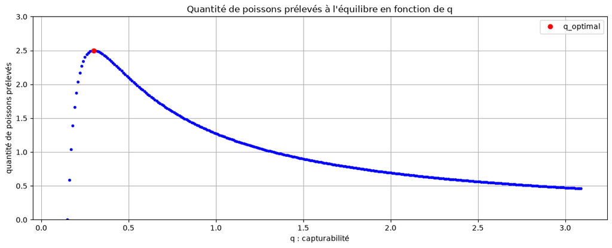

```python
# Tracé numérique de la fonction q → rc/pq(1 −c/pqK). (la quantité de poissons prélevée)
N = 300
q0 = 0.1; dq = 0.01
q = np.zeros(N)
r = 0.5                                   # taux de croissance
K = 20                                    # capacité limite du milieu
p = 1                                     # prix unitaire de vente du poisson
c = 3                                     # coût unitaire de l’effort de pêche

for i in range(N):
  q[i] = q0 + dq*i

fq = lambda r,c,p,q,K : r*c/(p*q)*(1 - c/(p*q*K))

display(Latex(f"La capturabilité au point maximal théorique est : $q_M = {(2*c/(p*K))}$."))
display(Latex(f"La quantité correspondante de poissons est : $h(q_M) = {fq(r, c, p, 2*c/(p*K), K)}$."))

fig, ax = plt.subplots(1,1, figsize=(14, 5))
ax.plot(q, fq(r,c,p,q,K), '.', color='blue')
ax.plot((2*c/(p*K)), fq(r, c, p, 2*c/(p*K), K), 'o', color='red', label = "q_optimal")
ax.set_title("Quantité de poissons prélevés à l'équilibre en fonction de q")
ax.set_xlabel('q : capturabilité')
ax.set_ylabel('quantité de poissons prélevés')
ax.set_ylim(0) # pour éviter les stocks négatifs
ax.grid()
plt.legend()
plt.show()
```

On voit que le résultat théorique (le point rouge) correspond bien à notre résultat numérique. Une capturabilité plus élevé ne veut pas dire que le stock prélevé sera plus important : la pression sur le stock devient trop forte. Cependant, si la capturabilité est plus faible que cette valeur maximale, le stock prélevé est bien plus faible.

## 3. Un deuxième modèle bio-économique : la demande en jeu

Retour à la table des matières  
Nous supposons maintenant que le prix du poisson $p(t)$ peut varier au cours du temps. En particulier, nous supposons que ce prix dépend de la demande. Le modèle économique est alors encore plus complexe, mais il permet de comprendre les relations unissant marchés financiers et industries.  
Nous suivons la même démarche que précédemment, mais cette fois-ci la complexité du modèle introduit une difficulté supplémentaire dans l'étude de la stabilité des solutions.

### A) Justification du modèle

Nous supposerons que le prix unitaire est fixé en fonction de le demande selon la fonction $D : p \longmapsto D(p)$. Cette dernière est une fonction décroissante en fonction du prix du poisson et de la quantité de poisson disponible à la vente. Nous considèrons alors un système couplé à trois inconnues :

$$ \begin{cases} \frac{dn}{dt} = r n(t) \left (1 - \frac{n(t)}{K} \right) - qn(t)E(t)\\ \frac{dE}{dt} = \left (p(t)qn(t) - c \right)E(t) \\ \frac{dp}{dt} = \frac{1}{\varepsilon}p(t)\cdot(D(p(t)) - qn(t)E(t)) \end{cases} \tag{3} $$

où $\varepsilon > 0$ (supposé petit) est un paramètre permettant de prendre en compte le fait que le temps caractéristique d'évolution de la quantité de poisson et celui de l'investissement soit beaucoup plus grand que celui sur les places financières du prix du poisson (rythme industriel et biologique contre rythme financier). En d'autres termes, **$p$ peut varier beaucoup plus vite que $n$ et $E$**.

Par la suite, nous admettrons pour simplifier que la demande dépend linéairement du prix du poisson : $D(p) = A - αp$, où $A > 0$ représente la demande maximum et $α > 0$, le facteur de variation du prix.

En particulier, il est possible de montrer que la limite d'un tel système lorsque le paramètre $\varepsilon$ tend vers $0$ conduit à un modèle réduit de la forme :

$$ \boxed{ \begin{cases} \frac{dn}{dt} = r n(t) \left (1 - \frac{n(t)}{K} \right) - qn(t)E(t)\\ \frac{dE}{dt} = \left (\frac{A-qn(t)E(t)}{\alpha}qn(t) - c \right)E(t) \end{cases}} \tag{3a} $$

Nous pouvons remarquer que la variable $p$ peut varier beaucoup plus vite que $n$ et $E$. Supposons donc que la dynamique rapide atteint son équilibre stable beaucoup plus vite que $n$ et $E$ lorque l'on se place dans une échelle de temps lente, ainsi :

$$\frac{dp}{dt} = \frac{1}{\epsilon}p(t) \left(D(p(t)) - qn(t)E(t) \right) = 0 \Longleftrightarrow D(p) - qnE = 0 \Longleftrightarrow A - \alpha p = qnE$$ $$ \Longleftrightarrow p = \frac{A-qnE}{\alpha}$$

En l'injectant au sein système $(3)$, nous obtenons le système $(3a)$.  
Ainsi nous pouvons définir **deux modèles possibles** selon la valeur prise par $\varepsilon$.

### B) Etude des points d'équilibre

Comme pour les deux modèles précédents nous cherchons à déterminer les points d'équilibre de ce modèle. Nous commencerons par une étude analytique du modèle. Par ailleurs étant donné la complexité du système $(3)$, nous nous contenterons de l'étude des points d'équilibre du modèle $(3a)$.

On résout les équations :
$$\begin{cases} \frac{dn}{dt} = 0\\ \frac{dE}{dt} = 0 \end{cases}\Longleftrightarrow \begin{cases} 0 = r n \left (1 - \frac{n}{K} \right) - qnE\\ 0 = \left (\frac{A-qnE}{\alpha}qn - c \right)E \end{cases} \Longleftrightarrow \begin{cases} n(t) = 0~~ou~~r(1-\frac{n}{K}) - qE = 0\\ E(t) = 0~~ou~~\frac{A - qnE}{\alpha}qn - c = 0 \end{cases} $$

On trouve alors l'habituel premier point d'équilibre $\boxed{(n_1, E_1) = (0,0)}$.

$$\Longleftrightarrow \begin{cases} n(t) = 0~~ou~~n = (\frac{r-qE}{r})K\\ E(t) = 0~~ou~~\frac{c\alpha}{q} = An -qn²E \end{cases} $$ Si $E = 0$ alors $n = K$, on a alors un deuxième point d'équilibre, similaire à celui du modèle $(2)$ $\boxed{(n_2, E_2) = (K,0)}$.
Puis si $n \not = 0$ : $$\Longleftrightarrow \begin{cases} n = (1-\frac{qE}{r})K\\ E = (An - \frac{c\alpha}{q})\frac{1}{qn²} \end{cases} \Longleftrightarrow \begin{cases} n = K - \frac{1}{rn²}(An - \frac{c\alpha}{q})K\\ E = (An - \frac{c\alpha}{q})\frac{1}{qn²} \end{cases} \Longleftrightarrow \begin{cases} n^3 = n²K - \frac{AK}{r}n + \frac{c\alpha}{rq}K\\ E = (An - \frac{c\alpha}{q})\frac{1}{qn²} \end{cases}$$ On se retrouve alors avec une équation du 3e degré à résoudre. On pose alors :
$an^3 + bn² + cn + d = 0$ avec $a = 1, b = -K, c = \frac{AK}{r}, d = - \frac{c\alpha}{rq}K$.

Pour cela nous utiliserons le module sympy de python. Les lignes `None` ci-dessous ne montrent que le fait que le module sympy a atteint une limite dans la simplification.

```python
r, K, c, a, q, A = sym.symbols('r, K, c, a, q, A', positive = True)
x = sym.Symbol("x")
solution = sym.solve((x**3 + (-K)*x**2 + (A*K/r)*x + (-c*a*K/(r*q))), x)
for i in range (len(solution)):
    print(display(sym.simplify(solution[i]))) #simplification de la solution au maximum et écriture en latex
```

$\displaystyle \frac{K}{3} + \frac{\frac{3 A K}{r} - K^{2}}{3 \sqrt[3]{\frac{9 A K^{2}}{2 r} - K^{3} - \frac{27 K a c}{2 q r} + \frac{\sqrt{- 4 \left(- \frac{3 A K}{r} + K^{2}\right)^{3} + \left(\frac{9 A K^{2}}{r} - 2 K^{3} - \frac{27 K a c}{q r}\right)^{2}}}{2}}} - \frac{\sqrt[3]{\frac{9 A K^{2}}{2 r} - K^{3} - \frac{27 K a c}{2 q r} + \frac{\sqrt{- 4 \left(- \frac{3 A K}{r} + K^{2}\right)^{3} + \left(\frac{9 A K^{2}}{r} - 2 K^{3} - \frac{27 K a c}{q r}\right)^{2}}}{2}}}{3}$

```
None
```

$\displaystyle \frac{K}{3} - \frac{\frac{3 A K}{r} - K^{2}}{3 \left(\frac{1}{2} + \frac{\sqrt{3} i}{2}\right) \sqrt[3]{\frac{9 A K^{2}}{2 r} - K^{3} - \frac{27 K a c}{2 q r} + \frac{\sqrt{- 4 \left(- \frac{3 A K}{r} + K^{2}\right)^{3} + \left(\frac{9 A K^{2}}{r} - 2 K^{3} - \frac{27 K a c}{q r}\right)^{2}}}{2}}} + \frac{\left(\frac{1}{2} + \frac{\sqrt{3} i}{2}\right) \sqrt[3]{\frac{9 A K^{2}}{2 r} - K^{3} - \frac{27 K a c}{2 q r} + \frac{\sqrt{- 4 \left(- \frac{3 A K}{r} + K^{2}\right)^{3} + \left(\frac{9 A K^{2}}{r} - 2 K^{3} - \frac{27 K a c}{q r}\right)^{2}}}{2}}}{3}$

```
None
```

$\displaystyle \frac{K}{3} - \frac{\frac{3 A K}{r} - K^{2}}{3 \left(\frac{1}{2} - \frac{\sqrt{3} i}{2}\right) \sqrt[3]{\frac{9 A K^{2}}{2 r} - K^{3} - \frac{27 K a c}{2 q r} + \frac{\sqrt{- 4 \left(- \frac{3 A K}{r} + K^{2}\right)^{3} + \left(\frac{9 A K^{2}}{r} - 2 K^{3} - \frac{27 K a c}{q r}\right)^{2}}}{2}}} + \frac{\left(\frac{1}{2} - \frac{\sqrt{3} i}{2}\right) \sqrt[3]{\frac{9 A K^{2}}{2 r} - K^{3} - \frac{27 K a c}{2 q r} + \frac{\sqrt{- 4 \left(- \frac{3 A K}{r} + K^{2}\right)^{3} + \left(\frac{9 A K^{2}}{r} - 2 K^{3} - \frac{27 K a c}{q r}\right)^{2}}}{2}}}{3}$

```
None
```

Les trois solutions sont commes attendues composées d'une réelle, et de deux complexes conjuguées (donc non physiques). Ce dernier point d'équilibre (première solution ci-dessus) a une expression qui est pour le moins compliquée.

Comme cette dernière solution n'est pas exactement simple à étudier, nous nous contenterons d'étudier l'attractivité des solutions $(n_1, E_1)$ et $(n_2, E_2)$. Nous utiliserons une approche numérique pour trouver la valeur de la solution $(n_3, E_3)$.  
Ensuite en étudiant la modélisation numérique et la figure de stabilité (on doit alors choisir un $\varepsilon$ assez petit pour être considéré dans le cas $(3a)$) on peut en déduire l'attractivité/répulsivité de ce dernier point.

Suite à des calculs fastidieux que vous retrouverez en annexe. On trouve :  
$(n_1, E_1) = (0,0)$ et $(n_2, E_2) = (K,0)$ correspondent à des régimes **instables** (ce sont donc des points répulsifs).

### C) Illustration numérique des résultats

```python
def Bio_eco_3(t, X, ε, A, α, r, K, q, c):
    n, E, p = X

    D = lambda p : A - α*p
    fn = lambda n, E : r*n*(1-n/K) - q*E*n
    fE = lambda n, E, p : (p*q*n - c)*E
    fp = lambda n, E, p : 1/ε*(D(p) - q*n*E)

    return fn(n, E), fE(n ,E, p), fp(n , E, p)

def RK4_2e_bio_eco_3(log_ε, A, α, r, K, q, c, n0, E0, p0, ti, tf, dt):
    ε = 10**log_ε

    T = np.arange(ti, tf, dt)
    X0 = (n0, E0, p0)

    sol = solve_ivp(Bio_eco_3, [ti, tf], X0, method='RK45', args=(ε, A, α, r, K, q, c), t_eval=T)
    n, E, p = sol.y

    return T, n, E, p

#######################################################################

def Bio_eco_4(t, X, A, r, K, q, c, α):
    n, E = X

    dndt = r * n * (1 - n / K) - q * E * n
    dEdt = ((A - q * n * E) / α * q * n - c) * E

    return dndt, dEdt

def RK4_2e_bio_eco_4(A, r, α, K, q, c, n0, E0, p0, ti, tf, dt):
    X0 = (n0, E0)

    T = np.arange(ti, tf, dt)

    sol = solve_ivp(Bio_eco_4, [ti, tf], X0, method='RK45', args=(A, r, K, q, c, α), t_eval=T)

    n, E = sol.y
    p = (A - q * n * E) / α
    p[0] = p0

    return T, n, E, p
```

La visualisation Python permet de mettre en évidence que, pour le système $(3)$, lorsque $\varepsilon$ tend vers $0$, ici lorsque $log(\varepsilon) < -10 \Longleftrightarrow \varepsilon < 10^{-10}$, l'évolution obtenue ressemble beaucoup à celle du système $(3a)$.  
Pour trouver cette valeur de $\varepsilon$, il suffit de juste à faire varier le widget ci-dessous et de comparer les résultats des modèles pour vérifier quelle était la valeur seuil de $\varepsilon$ pour laquelle les deux systèmes étaient équivalents.

```python
############################ paramètres ###################################
r = 0.5                                   # taux de croissance
K = 20                                    # capacité limite du milieu
q = 0.4                                   # paramètre de capturabilité
c = 1                                     # coût unitaire de l’effort de pêche

log_ε = (-100, 10, 0.1)                   # logarithme décimal de temps caractéristique d’évolution de la quantité de poisson
A = (0, 20, 1)                            # demande maximale
α = 1                                     # facteur de variation du prix

E0 = (0, r/q, 0.1)                        # effort de pêche initial
n0 = (0, K, 1)                            # quantité de poissons initiale
p0 = (0.5, 3, 0.5)                        # prix unitaire de vente du poisson initiale

ti = 0
tf = 700
dti = (0.01, 0.1, 0.01)   # intervalle pour le pas de temps pour le interact

########################### affichage ######################################
@interact
def interact_bio3(log_ε=log_ε, r=fixed(r), K=fixed(K), q=fixed(q), α=fixed(α), p0=p0, c=fixed(c), E0=E0, n0=n0, ti=fixed(ti)
                  , tf=fixed(tf), dti=dti, A=A):
    dt = dti
    ##### choix du système
    if log_ε >= -10:
        T, n, E, p = RK4_2e_bio_eco_3(log_ε, A, α, r, K, q, c, n0, E0, p0, ti, tf, dt) # système 3
    else:
        T, n, E, p = RK4_2e_bio_eco_4(A, r, α, K, q, c, n0, E0, p0, ti, tf, dt)  # système 4

    display(Latex(f'Stock final : $n^f = {round(n[-1],3)}$ & effort de pêche final : $E^f = {round(E[-1],3)}$'))
    # solution du troisème équilibre
    x = sym.Symbol("x")
    solution = sym.solve((x**3 + (-K)*x**2 + (A*K/r)*x + (-c*α*K/(r*q))), x)
    display(Latex(f"Troisème couple calculé via sympy : $(n_3, E_3) = ({round(solution[0], 3)}, {round((A*solution[0] - c*α/q)/(q*solution[0]**2), 3)})$"))
    ##### affichage
    fig, ax = plt.subplots(1, 1, figsize=(14, 5))
    ax.plot(T, n, '-b', label='Quantité de poissons')
    ax.plot(T, E, '-r', label='Effort de pêche')
    ax.plot(T, p, '-g', label='Prix unitaire de vente du poisson')

    ax.legend(bbox_to_anchor=(1.05, 1.0), loc="upper left")
    ax.set_title("Évolution des paramètres au cours du temps")
    ax.grid()
    #fig, ax = plt.subplots(1, 2, figsize=(14, 5)) ####### c'est pour montrer que les deux sont bien dissipatifs ;)
    #ax[0].plot(T, n, '-b', label='Quantité de poissons')
    #ax[1].plot(T, E, '-r', label='Effort de pêche')

############ étude de l'attractivité / stabilité ###########
    ns0 = [0, n0/3, solution[0], 1.2*n0, 2*n0]  # différents points de départ
    es0 = [0, E0/3, (A*solution[0] - c*α/q)/(q*solution[0]**2), 1.2*E0, 2*E0]  # différents points de départ
    ps0 = [p0/8, p0]  # différents points de départ

    fig, ax = plt.subplots(1, 1, figsize=(6, 4))

    for pi in ps0:
        for ei in es0:
            for ni in ns0:
                if log_ε >= -10:  # pour (3) problème de dt, vu comme un tuple ????
                    T, n, E, p = RK4_2e_bio_eco_3(log_ε, A, α, r, K, q, c, ni, ei, pi, ti, tf, dt)  # système 3
                else:
                    T, n, E, p = RK4_2e_bio_eco_4(A, r, α, K, q, c, ni, ei, pi, ti, tf, dt)  # système 4
                ax.plot(n, E, label=f"pour n0 = {round(ni, 3)} et e0 = {round(ei, 3)}")
                ax.plot(n[-1], E[-1], marker='o', color='red')

    ax.set_title("étude de la stabilité avec E = f(n)")
    ax.set_xlabel('stock de poisson')
    ax.set_ylabel('Effort de pêche')
    # ax.legend(bbox_to_anchor=(1.05, 1.0), loc="upper left")
    ax.grid()
```

```
interactive(children=(FloatSlider(value=-45.0, description='log_ε', max=10.0, min=-100.0), FloatSlider(value=1…
```

Ainsi, ici on remarque que la solution $(n_3, E_3)$ est bien une solution attractive. Nous n'avions pas pu le prouver analytiquement mais la visualisation numérique est claire grâce à ce graphique.

Il est intéressant de noter que **les solutions prennent du temps à se stabiliser** (d'où ici $t^f = 700$), et ce, particulièrement lorsque la demande maximum $A$ est grande. *$A$ est le seul paramètre de départ* (parmi ceux amenés à varier ici) qui, selon sa valeur, peut *faire varier la stabilité des solutions*. Ceci paraît assez cohérent physiquement puisque si la demande est trop grande, alors l'effort de pêche varie de façon importante et par conséquence, le stock de poissons fait de même.

Analytiquement, c'est compréhensible comme nous avons : $\frac{dE}{dt} = \left (\frac{A-qnE}{\alpha}qn - c \right)E$. Ainsi si $A$ est très élevé, comme la variation de $E$ est proportionnelle à $A$ et l'effort de pêche oscillera très fortement dès le début.

## 4. Un modèle multi-sites

Retour à la table des matières

Dans ce pénultième modèle, nous supposons maintenant qu'il existe plusieurs sites de pêche, que les poissons peuvent se déplacer entre les sites en passant par une **zone libre** (dans laquelle la pêche n'est pas autorisée). Les bateaux de pêche peuvent aussi se déplacer entre les sites.

### A) Etude liminaire du modèle

La figure (1) ci-dessous présente une illustation de ce nouveau modèle :

[figure not shown]

Figure 1: Schéma d'un modèle multi-sites de pêche - Les sites sont des dispositifs à concentration de poissons (DCP).

Pour chaque site $i \ (i = 1, . . . , L)$, nous allons introduire une quantité de poissons $n_i$, et un effort de pêche $E_i$. La zone libre (free stock), contient $n_s$ quantité de poissons. Comme précédemment, chaque site va introduire son jeu de paramètres. Nous introduisons aussi des paramètres relatifs aux mouvements des poissons entre les différents sites ainsi que le déplacement des bateaux de pêches :

- $(K_1, K_2,..., K_L)~;~K_s$: capacité de chaque site et de la zone libre.
- $\beta_{i,j}$ : taux de déplacement de bateaux d'un site $j$ vers un site $i$ en supposant une symétrie de déplacement $(\beta_{i,j} = \beta_{j,i})$.
- $m_{i,j}$ : taux de déplacement de poissons d'un site $j$ vers un site $i$ en supposant que ce taux est inversement proportionnel à la capacité du site de départ: $m_{i,j} = \frac{m}{K_j}$ .

Comme précédemment, nous allons introduire un petit paramètre $\varepsilon$ témoignant du fait que les échanges entre sites s'effectue à une échelle de temps beaucoup plus rapide que l'évolution de la biomasse de poisson. Le système devient :

$$\boxed{ \begin{cases} \frac{dn_s}{dt} = \frac{1}{\varepsilon} \left (\sum_{i=1}^L m_{si}n_i - \sum_{i=1}^L m_{is}n_s \right) + rn_s \left (1 - \frac{n_s}{K_s} \right)\\ \frac{dn_i}{dt} = \frac{1}{\varepsilon} \left (m_{is}n_s - m_{si}n_i \right) + \left (rn_i \left (1 - \frac{n_i}{K_i} \right ) - qn_iE_i \right) \ \ \text{avec $i \in$ {$1,...,L$}} \\ \frac{dE_i}{dt} = \frac{1}{\varepsilon} \left (\beta_{i,i-1}E_{i-1} + \beta_{i,i+1}E_{i+1} - \left ( \beta_{i-1,i} + \beta_{i+1,i} \right)E_i \right) + (pqn_i - c)E_i \ \ \text{avec $i \in$ {$1,...,L$}} \end{cases}} \tag{4} $$

On essaye maintenant de simplifier le système pour pouvoir le modéliser numériquement par la suite. Le détail de la démonstration est disponible en annexe. On trouve :

$$ \boxed{ \begin{cases} \frac{dn}{dt} = r n \left (1 - \frac{n}{K} \right) - n Q E \\ \frac{dE}{dt} = \left (- c + p n Q \right) E \end{cases}} \tag{4a} $$

### B) Etude numérique du modèle

Le modèle utilisé dépend de la valeur prise par $\varepsilon$.

Résultats pour le modèle $(4)$ :  
*Attention : pour un pas de temps $dt < 10^{-4}$ le graphique met beaucoup de temps à s'afficher... À vos risques et périls.*

```python
### La solution au cours du temps de ce système en fonction des paramètres du modèle.
###########################pramètres pour les deux modèles################""
r = 0.9                                   # taux de croissance
L = 7                                     # nombre total des sites
m = (7, 12, 1)                            # taux de deplacement de poissons

log_ε = (-4, 0, 1)                      # logarithme décimal de temps caractéristique d’évolution de la quantité de poisson
Ks = (15, 20, 1)                          # capacité limite de la zone libre
Ki = np.array([10,12,8,15,10,13,12])      # capacité limite de chaque site
K = (85, 200, 1)                          # capacité limite totale du mileu

q = 0.4                                   # paramètre de capturabilité

p = 0.5                                   # prix unitaire de vente du poisson
c = 1.5                                   # coût unitaire de l’effort de pêche

n0 = 10
ns = 4
ni = np.array([1.2,0.5,1.2,0.5,1,1,0.6])            # quantité de poissons initiale
E0 = 0.6
Ei = np.array([0.1,0.08,0.04,0.08,0.08,0.1,0.12])   # effort de pêche initial de chaque site

βs = np.array([[0, 2, 3, 1, 5, 4, 7],      # une matrice des taux de déplacement de bateaux d’un site j vers un site i (βi,j = βj,i)
              [2, 0, 4, 3, 2, 5, 1],
              [3, 4, 0, 6, 7, 1, 2],
              [1, 3, 6, 0, 8, 7, 1],
              [5, 2, 7, 8, 0, 3, 5],
              [4, 5, 1, 7, 3, 0, 4],
              [7, 1, 2, 1, 5, 4, 0]])

ti = 0; tf = 50
log_dt = (-5, 0, 1)
```

```python
def Multi_site_5(X, A, ε, L, r, K, Ks, Ki, m, p, q, c, dt):
    ns, ni, Ei = X

    fns = lambda ns, ni, Ei : 1/ε*(sum(m/Ki*ni - m/Ks*ns)) + r*ns*(1-ns/Ks)
    fni = lambda ns, ni, Ei : 1/ε*(m/Ks*ns - m/Ki*ni) + (r*ni*(1-ni/Ki) - q*ni*Ei)
    fEi = lambda ns, ni, Ei : 1/ε*A@Ei + (p*q*ni-c)*Ei

    K1 = (fns(ns, ni, Ei), fni(ns, ni, Ei), fEi(ns, ni, Ei))
    ns1, ni1, Ei1 = K1

    K2 = (fns(ns + dt/2*ns1, ni + dt/2*ni1, Ei + dt/2*Ei1), fni(ns + dt/2*ns1, ni + dt/2*ni1, Ei + dt/2*Ei1),
          fEi(ns + dt/2*ns1, ni + dt/2*ni1, Ei + dt/2*Ei1))
    ns2, ni2, Ei2 = K2

    K3 = (fns(ns + dt/2*ns2, ni + dt/2*ni2, Ei + dt/2*Ei2), fni(ns + dt/2*ns2, ni + dt/2*ni2, Ei + dt/2*Ei2),
          fEi(ns + dt/2*ns2, ni + dt/2*ni2, Ei + dt/2*Ei2))
    ns3, ni3, Ei3 = K3

    K4 = (fns(ns + dt*ns3, ni + dt*ni3, Ei + dt*Ei3), fni(ns + dt*ns3, ni + dt*ni3, Ei + dt*Ei3),
          fEi(ns + dt*ns3, ni + dt*ni3, Ei + dt*Ei3))
    ns4, ni4, Ei4 = K4

    return ns + dt/6*(ns1 + 2*ns2 + 2*ns3 + ns4), ni + dt/6*(ni1 + 2*ni2 + 2*ni3 + ni4), Ei + dt/6*(Ei1 + 2*Ei2 + 2*Ei3 + Ei4)


def RK4_multi_site_5(log_ε, L, r, K, Ks, Ki, m, p, q, c, ns0, ni0, Ei0, ti, tf, log_dt):
    # Initialisation:
    ε = 10**log_ε
    dt = 10**log_dt
    print(f"ε = {ε}, dt = {dt}")
    N = int((tf-ti)/dt)+1

    T = np.zeros(N)

    V_ns = np.zeros(N)
    M_ni = np.zeros((N,L))
    M_Ei = np.zeros((N,L))

    V_ns[0] = ns0
    M_ni[0] = ni0
    M_Ei[0] = Ei0

    X = (ns0, ni0, Ei0)

    ##############
    # Définie la matrice A pour dEi/dt = 1/ε*A@Ei + B*Ei (B = p*q*ni-c)
    As = np.zeros((L,L))

    for j in range(0,L-1):
        As[j,j-1] = βs[j,j-1]
        As[j,j] = -(βs[j-1,j] + βs[j+1,j])
        As[j,j+1] = βs[j,j+1]

    # condition aux bornes de A
    As[L-1,L-2] = βs[L-1,L-2]
    As[L-1,L-1] = -(βs[L-2,L-1] + βs[0,L-1])
    As[L-1,0] = βs[L-1,0]
    ##############

    for i in range(N):
        T[i] = ti + i*dt

        X = Multi_site_5(X, As, ε, L, r, K, Ks, Ki, m, p, q, c, dt)
        V_ns[i], M_ni[i], M_Ei[i] = X
        #print(f"Step {i}, ns = {V_ns[i]}, ni = {M_ni[i]}, Ei = {M_Ei[i]}")  # Debug print

    # Évolution au cours du temps de n, E et calcul K :
    V_n = V_ns + sum(M_ni.T)
    V_E = sum(M_Ei.T)
    K = Ks + sum(Ki)

    print('n fin = ', round(V_n[-1],3), '; E fin = ',round(V_E[-1],3))

    return T, V_n, V_E
```

```python
@interact
def interact_modele5(log_ε=log_ε, L=fixed(L), r=fixed(r), K=K, Ks=Ks, Ki=fixed(Ki), m=m, p=fixed(p), q=fixed(q), c=fixed(c),
                     ns0=fixed(ns), ni0=fixed(ni), Ei0=fixed(Ei), ti=fixed(ti), tf=fixed(tf), log_dt=log_dt):
    T, V_n, V_E = RK4_multi_site_5(log_ε, L, r, K, Ks, Ki, m, p, q, c, ns0, ni0, Ei0, ti, tf, log_dt)
    # Partie graphique :
    fig, ax = plt.subplots(1,3, figsize=(14, 5))

    ax[0].plot(T, V_n, '-b')
    ax[0].set_title("Évolution de la quantité de poissons")
    ax[0].grid()

    ax[1].plot(T, V_E, '-r')
    ax[1].set_title("Évolution de l'effort de pêche")
    ax[1].grid()

    ax[2].plot(V_n, V_E, '.r')
    ax[2].set_title("E = f(n)")
    ax[2].grid()
```

```
interactive(children=(IntSlider(value=-2, description='log_ε', max=0, min=-4), IntSlider(value=142, descriptio…
```

Résultats pour le modèle $(4a)$ :

```python
def Multi_site_6(t, X, r, K, Q, p, c):
    n, E = X

    fn = lambda n, E : r*n*(1-n/K) - Q*E*n
    fE = lambda n, E : (p*Q*n - c)*E

    return fn(n, E), fE(n, E)


def RK4_multi_site_6(r, K, Q, p, c, n0, E0, ti, tf, log_dt):
    dt = 10**log_dt
    T = np.arange(ti, tf, dt)

    X0 = (n0, E0)

    sol = solve_ivp(Multi_site_6, [ti, tf], X0, method='RK45', args=(r, K, Q, p, c), t_eval=T)
    n, E = sol.y
    print('n fin = ', round(n[-1],3), '; E fin = ',round(E[-1],3))

    return T, n, E


@interact
def interact_modele6(L=fixed(L), r=fixed(r), K=K, Ks=Ks, Ki=fixed(Ki), m=m, p=fixed(p), q=fixed(q), c=fixed(c),
                     ns0=fixed(ns), ni0=fixed(ni), Ei0=fixed(Ei), ti=fixed(ti), tf=fixed(tf), log_dt=log_dt):
    α = Ks/K
    Q = q*(1-α)/L
    T, n, E = RK4_multi_site_6(r, K, Q, p, c, n0, E0, ti, tf, log_dt)

    fig, ax = plt.subplots(1,3, figsize=(14, 5))

    ax[0].plot(T, n, '-b')
    ax[0].set_title("Évolution de la quantité de poissons")
    ax[0].grid()

    ax[1].plot(T, E, '-r')
    ax[1].set_title("Évolution de l'effort de pêche")
    ax[1].grid()

    ax[2].plot(n, E, '.r')
    ax[2].set_title("E = f(n)")
    ax[2].grid()

################################################################################
```

```
interactive(children=(IntSlider(value=142, description='K', max=200, min=85), IntSlider(value=17, description=…
```

Les modèles $(4)$ et $(4a)$ sont plutôt similaires même si le modèle $(4a)$ met un peu plus de temps à se stabiliser. Par ailleurs, on peut bien voir que les deux modèles sont d'autant plus similaires lorsque $K$ est inférieur à 100. C'est-à-dire que plus $K$ est grand, moins l'approximation peut être considérée comme correcte, et l'on se retrouve alors avec des problèmes de stabilité.

### C) Comparaison des modèles $(3)$ et $(4)$

Pour mieux voir l'effet de la création des aires marines protégées, sites où la pêche est interdite (théoriquement du moins, et ce seulement pour un niveau de protection élevé), on compare deux modèles étudiés : bio-économique $(3)$ et multi-sites $(4)$.

```python
r = 0.9                                   # taux de croissance
Ks = 15                                   # capacité limite de la zone libre
K = 85                                    # capacité limite du milieu
q = 0.4                                   # paramètre de capturabilité
c = 1.5                                   # coût unitaire de l’effort de pêche
L = 7                                     # nombre total des sites

log_ε = (-4, 2, 0.1)                      # logarithme décimal de temps caractéristique d’évolution de la quantité de poisson
A = (10, 35, 5)                           # demande maximum
α = Ks/K                                  # facteur de variation du prix

E0 = 0.6                                  # effort de pêche initial
n0 = 10                                   # quantité de poissons initiale

ti = 0; tf = 100
dt = (0.01, 0.06, 0.01)

##########################################################################################################################
def comparer_modele_3_et_4(L, A, r, α, K, q, c, n0, E0, ti, tf, dt):
    Q = q*(1-α)/L
    X0 = [n0, E0]

    T = np.arange(ti, tf, dt)

    sol3 = solve_ivp(Bio_eco_4, [ti, tf], X0, method='RK45', args=(A, r, K, q, c, α), t_eval=T)
    sol4 = solve_ivp(Multi_site_6, [ti, tf], X0, method='RK45', args=(r, K, Q, p, c), t_eval=T)

    n3, E3 = sol3.y
    n4, E4 = sol4.y

    fig, ax = plt.subplots(1,1, figsize=(14, 5))
    ax.plot(T, n3, '-b', label = 'Quantité de poissons du modèle bio-éconimique')
    ax.plot(T, n4, '--b', label = 'Quantité de poissons du modèle multi-sites')
    ax.set_xlabel("Temps d'évolution")
    ax.set_ylabel("Quantité de poissons")
    ax.legend(bbox_to_anchor=(1.05, 1.0), loc="upper left")
    ax.grid()

    fig, ax = plt.subplots(1,1, figsize=(14, 5))
    ax.plot(T, E3, '-r', label = 'Effort de pêche du modèle bio-éconimique')
    ax.plot(T, E4, '--r', label = 'Effort de pêche du modèle multi-sites')
    ax.set_xlabel("Temps d'évolution")
    ax.set_ylabel("Effort de pêche")
    ax.legend(bbox_to_anchor=(1.05, 1.0), loc="upper left")
    ax.grid()

    fig, ax = plt.subplots(1,2, figsize=(14, 5))
    ax[0].plot(n3, E3, '-g')
    ax[0].set_xlabel('n3')
    ax[0].set_ylabel('E3')
    ax[0].set_title('E3 = f(n3)')
    ax[0].grid()

    ax[1].plot(n4, E4, '--g')
    ax[1].set_xlabel('n4')
    ax[1].set_ylabel('E4')
    ax[1].set_title('E4 = g(n4)')
    ax[1].grid()

################################################################################
# Exécution :
interact(comparer_modele_3_et_4, L=fixed(L), A=A, α=fixed(α), r=fixed(r), K=fixed(K), q=fixed(q), c=fixed(c), n0=n0, E0=fixed(E0), ti=fixed(ti), tf=fixed(tf), dt=dt)

plt.show()
```

```
interactive(children=(IntSlider(value=20, description='A', max=35, min=10, step=5), IntSlider(value=10, descri…
```

À partir de ces deux figures, on peut en déduire l'avantage de la gestion des zones de pêche en contrôlant la quantité de milieu autorisé à la pêche. En effet, on peut constater qu'après l'installation d'un nombre adéquat d'aires marines protégées, les trajectoires quittent le cycle limite et se stabilisent autour d'un équilibre stable, ce qui représente une pêche durable.

## 5. Un modèle bi-espèces pour aller plus loin

Retour à la table des matières

Après avoir étudié les quatre modèles précédents, nous avons décidé d'élaborer notre propre modèle qui permet la cohabitation de deux espèces. Nous avons choisi d'avoir des thons et des sardines dans un même milieu.

### A) Présentation du modèle

On souhaite modéliser deux populations de poisson se trouvant dans un même bassin et étant soumis à un régime de pêche. On choisit une population de sardines (espèce s) coexistant avec une population de thons (espèce t). Nous étudions donc le modèle complexe composé des modèles basiques suivants : un modèle dit de Lotka-Volterra proie-prédateur puisque le thon est un prédateur de la sardine : $$ \begin{cases} \frac{dx_s}{dt}(t) = x_s(t) (\alpha - \beta x_t(t)) \\ \frac{dx_t}{dt}(t) = x_t(t) (\delta x_s(t) - \gamma) \end{cases} \Longleftrightarrow \begin{cases} \frac{dx_s}{dt}(t) = {\rm reproduction~des~sardines - prédation~des~thons} \\ \frac{dx_t}{dt}(t) = {\rm fruit~de~la~prédation - mortalité~des~thons} \end{cases} \tag 7 $$

avec :

- $x_s(t)$ le stock de sardines ;
- $x_s(t)$ le stock de thons ;
- $\alpha$ le taux de reproduction des proies ;
- $\beta$ le taux de mortalité des proies (à cause des prédateurs) ;
- $\delta$ le taux de reproduction des prédateurs ;
- $\gamma$ le taux de mortalité des prédateurs.

Un modèle bio-économique (notre modèle 2) où on a une évolution des stocks de poisson et une évolution de l'effort de pêche : $$ \begin{cases} \frac{dx_i}{dt}(t) = r_i x_i(t)(1-\frac{x_i(t)}{K}) - q_i E_i(t)x_i(t) \\ \frac{dE_i}{dt}(t) = (pqx_i(t)-c) E_i(t) \end{cases} \tag 8 $$ avec :

- $K$ la capacité limite du milieu qui dépend uniquement du bassin étudié et est donc la même pour les deux types de poissons ;
- $q_i$ la capturabilité d'une espèce $i$ ;
- $r_i$ le taux de croissance de la population, il peut être assimilé au taux de reproduction. Ce qui donne donc $(r_1, r_2) = (\alpha, \delta)$ ;
- $p_i$ le prix unitaire de vente de l'espèce ;
- $E_i$ l'effort de pêche qui est spécifique à chaque espèce dans ce cas-ci (les moyens déployés par l'industrie halieutique sont différents pour chaque espèce).

Si on veut coupler nos deux systèmes d'équations, on se rend compte que l'évolution des stocks suit ce principe : $$ \begin{cases} \frac{dx_s}{dt}(t) = { \rm reproduction~des~sardines~qui~dépend~du~milieu - pêche~des~sardines - prédation~des~thons} \\ \frac{dx_t}{dt}(t) = { \rm - mortalité~des~thons + fruit~de~la~prédation - pêche~des~thons} \end{cases} $$
Tandis que les efforts de pêche ne dépendent que du stock de l'espèce qui définit cet effort de pêche. On se retrouve avec ce système de quatre équations: $$ \begin{cases} \frac{dx_s}{dt}(t) = \alpha x_s(t)(1-\frac{x_s(t)}{K}) - q_s E_s(t)x_s(t) - \beta x_s(t)x_t(t) \\ \frac{dx_t}{dt}(t) = -\gamma x_t(t) + \delta x_s(t)x_t(t) - q_t E_t(t)x_t(t) \\ \frac{dE_s}{dt}(t) = (p_sq_sx_s(t)- c_s) E_s(t) \\ \frac{dE_t}{dt}(t) = (p_tq_tx_t(t)- c_t) E_t(t) \\ \end{cases} \tag {9} $$

On peut noter que si les deux efforts de pêche sont nuls ($E_t = E_s = 0$) et la capacité du milieu trop grande pour être prise en compte ($K\longrightarrow +\infty$), alors on retombe bien sur l'équation de Lotka-Volterra pour le stock des sardines prédatées.  
Inversement, si on considère qu'il n'y a pas de prédation des thons ($\beta = 0$), alors on retombe sur la première équation du deuxième modèle $(2)$. Ainsi notre modèle est cohérent du point de vue analytique quant à l'interaction des variables.

### B) Représentation numérique

```python
#résolution
############## fonction modèle bi-espèces  ############################
def bi_especes (t, X, α, δ, β, γ, K, qs, qt, ps, pt, ct, cs):
    ns, Es, nt, Et = X
    fns = lambda ns, nt, Es : α*ns*(1-ns/K) - qs*Es*ns - β*ns*nt
    fnt = lambda ns, nt, Et : -γ*nt + δ*ns*nt - qt*Et*nt
    fEs = lambda ns, Es : (ps*qs*ns - cs)*Es
    fEt = lambda nt, Et : (pt*qt*nt - ct)*Et

    return fns(ns, nt, Es), fEs(ns, Es), fnt(ns, nt, Et), fEt(nt, Et)

def RK4_bi_especes(α, δ, β, γ, K, qs, qt, ps, pt, ct, cs, Es0, ns0, Et0, nt0, ti, tf, dt):
    T = np.arange(ti, tf, dt)
    X0 = (ns0, Es0, nt0, Et0)

    sol = solve_ivp(bi_especes, [ti, tf], X0, method='RK45', args=(α, δ, β, γ, K, qs, qt, ps, pt, ct, cs), t_eval=T)
    ns, Es, nt, Et = sol.y

    return T, ns, Es, nt, Et
```

```python
################### Paramètres ##############################################
α = 7 ; δ = 3                             # taux de croissance de s : sardine et t : thon
β = 3 ; γ = .5                             # taux de mortalité de s et 2s
K = 1000                                   # capacité limite du milieu
qs = 0.6 ; qt = 0.3                       # paramètre de capturabilité
ps = 0.5 ; pt = 0.7                       # prix unitaire de vente du poisson
cs = 0.09 ; ct = 0.09                         # coût unitaire de l’effort de pêche

Es0 = (0, 50, 0.1); Et0 = (0, 50, 0.1)  # effort de pêche initial
ns0 = (0, 10, 1) ; nt0 = (0, 10, 1)           # quantité de poissons initiale

ti = 0; tf = 2000                                #temps de simulation
dti = (0.01, 1, 0.01)
#############################################################################


@interact
def interact_bi_especes(α=fixed(α), δ=fixed(δ), β=fixed(β), γ=fixed(γ), K=fixed(K), qs=fixed(qs),
                    qt=fixed(qt), ps=fixed(ps), pt=fixed(pt), cs=fixed(cs), ct=fixed(ct),
                    Es0=Es0, Et0=Et0, ns0=ns0, nt0=nt0, ti=fixed(ti), tf=fixed(tf), dti=dti):
    dt = dti/10
    T, ns, Es, nt, Et = RK4_bi_especes(α, δ, β, γ, K, qs, qt, ps, pt, ct, cs, Es0, ns0, Et0, nt0, ti, tf, dt)
    print('ns_fin = ', round(ns[-1],3), '; Es_fin = ',round(Es[-1],3))
    print('nt_fin = ', round(nt[-1],3), '; Et_fin = ',round(Et[-1],3))

######################################################################### premiere partie :
    fig, ax = plt.subplots(1,1, figsize=(14, 5))
    ax.plot(T, ns, '--g', label = "stock de sardines")
    ax.plot(T, -nt, '--r', label = "stock de thons")
    ax.set_title("Évolution de la quantité de poissons")
    ax.set_xlabel('Temps')
    ax.set_ylabel('Stocks de poissons')
    ax.grid()
    ax.legend()

    fig, ax = plt.subplots(1,1, figsize=(14, 5))
    ax.plot(T, Es, '--g', label = "Effort de pêche des sardines")
    ax.plot(T, Et, '--r', label = "Effort de pêche des thons")
    ax.set_title("Évolution de l'effort de pêche")
    ax.set_xlabel('Temps')
    ax.set_ylabel('Efforts de pêche')
    ax.grid()
    ax.legend()

    fig, ax = plt.subplots(1,3, figsize=(14, 5))
    ax[0].plot(ns[-1000:], nt[-1000:], '--r')
    ax[0].set_title("Évolution de la population de thons en fonction des sardines")
    ax[0].set_xlabel('xs : population de sardines')
    ax[0].set_ylabel('xt : population de thons')
    ax[0].grid()

    ax[1].plot(ns[-1000:], Es[-1000:], '--g')
    ax[1].set_title("Es = f(xs)")
    ax[1].grid()

    ax[2].plot(nt[-1000:], Et[-1000:], '--r')
    ax[2].set_title("Et = f(xt)")
    ax[2].grid()

########################## portraits de phase ###########################################
    fns = lambda ns, nt, Es : α*ns*(1-ns/K) - qs*Es*ns - β*ns*nt
    fnt = lambda ns, nt, Et : -γ*nt + δ*ns*nt - qt*Et*nt
    fEs = lambda ns, Es : (ps*qs*ns - cs)*Es
    fEt = lambda nt, Et : (pt*qt*nt - ct)*Et

    fig, ax = plt.subplots(2,2, figsize=(14, 8))
    ax[0,0].plot(ns[-1000:], fns(ns[-1000:], nt[-1000:], Es[-1000:]), '.g', markersize = 1)
    ax[0,0].set_title("Diagramme de phase xs")
    ax[0,0].grid()

    ax[0,1].plot(nt[-1000:], fnt(nt[-1000:], nt[-1000:], Et[-1000:]), '.r', markersize = 1)
    ax[0,1].set_title("Diagramme de phase xt")
    ax[0,1].grid()

    ax[1,0].plot(Es[-500:], fEs(ns[-500:], Es[-500:]), '.g', markersize = 1)
    ax[1,0].set_title("Diagramme de phase Es")
    ax[1,0].grid()

    ax[1,1].plot(Et[-500:], fEt(nt[-500:], Et[-500:]), '.r', markersize = 1)
    ax[1,1].set_title("Diagramme de phase Et")
    ax[1,1].grid()
```

```
interactive(children=(FloatSlider(value=25.0, description='Es0', max=50.0), FloatSlider(value=25.0, descriptio…
```

NB : Nous avons choisi de représenter les stocks en miroir pour plus de visibilité. En effet, nous voulions visualiser les stocks jusqu'à atteindre un équilibre, ce qui nécessitait d'avoir un temps de simulation assez long. Or l'affichage est alors si dense que les valeurs au premier plan obèrent celles au second.

Pour ces valeurs-ci, l'on peut voir apparaître un **cycle limite** : le modèle ne converge plus vers un point d'équilibre attractif mais se stabilise en un cycle instable qui se déplace au cours du temps. Notre hypothèse est que ce cycle est a minima pseudo-périodique, mais nous ne savons pas l'étudier d'un point de vue analytique. En poussant la simulation sur un temps très long, le stock semble atteindre un **une pseudo-périodicité**, mais nous ne savons pas si celle-ci n'est qu'hypothétique ou pas. Cela semble être clairement le cas pour les stocks, et les diagrammes de phases des efforts de pêche semblent aller en ce sens mais il est plus difficile de l'affirmer à cause du tassement au bas des "oeufs" décrits, qui empêchent de conclure même en augmentant le nombre de points montrés.

Nous allons ensuite montrer les différents cas trouvés selon les valeurs des paramètres.